# Step 1: Read in and normalize data

Sam Pring, Sarah Lower, Brian Vestal

2025-03-12

**Goal: To read in data and check normalization**

# Ready the workspace

## Load packages

```r
#installation if necessary
if (!require("BiocManager", quietly = TRUE)) {install.packages("BiocManager")}
if (!requireNamespace("devtools", quietly = TRUE)) {install.packages("devtools")}
if (!require("tidyverse")) install.packages("tidyverse")

#if needed for installation
#BiocManager::install("rhdf5")
#BiocManager::install("tximport")
#BiocManager::install("DESeq2")
#BiocManager::install("tximeta")
#install.packages("tidyselect")
#devtools::install_github("thomasp85/patchwork")

#loading in the data
library(rhdf5) # allows for the handling of hdf5 file formats
library(tidyverse)
library(tximport) # package for getting Salmon results into R
library(datapasta) # allows for copy and pasting
library(DESeq2)
library(SummarizedExperiment)
library(tximeta)

#filtering and normalization
#BiocManager::install("vsn")
library(edgeR)
library(matrixStats)
library(cowplot)
library(hexbin)
library(vsn)
library(dplyr)
library(readr)

#making pretty figures
library(ggplot2)
library(patchwork)
```

## Clear workspace

```r
rm(list = ls())
```

# Read in data

- Gene-level analysis

### Read in sample metadata

```r
#read in sample metadata
meta <- read.delim("study_design.txt", header = TRUE, as.is = TRUE)

#make the SAMPLE column the rownames
rownames(meta) <- meta$SAMPLE

#add a names column (for lmerSeq later)
meta$names <- meta$SAMPLE
```

### Import Salmon quant files

```r
#Check that all sample quant.sf files from Salmon are present
salmonfiles <- paste0(meta$FILE, "/quant.sf")
names(salmonfiles) <- meta$SAMPLE
stopifnot(all(file.exists(salmonfiles)))

## Add a column "files" to the metadata table. This table must contain at least
## two columns: "names" (see previous code chunk) and "files"
coldata <- cbind(meta, quantfiles = salmonfiles, stringsAsFactors = FALSE)
```

```r
#Import quantifications at the gene level using tximport

#get annotations for transcripts by loading file from ncbi ---- WAS EDITED TO MATCH ORs ADDED FROM Mitchell's ANNOTATION----
annotation_file <- ("Ppyr_annotations_ORmodified_2025_03_12.tsv")

Tx <- read_tsv(annotation_file, col_names = c("target_id", "gene_name", "name", "PpyrOR"), col_types = "cccc")

Tx <- as_tibble(Tx)

#transcript ID needs to be the first column in the dataframe
Tx <- dplyr::select(Tx, "target_id", "gene_name")

#import Salmon transcript counts into R using Tximport ----
#import at gene level (txOut = FALSE), because transcript level analysis is mostly for differential transcript usage analysis -
Txi_gene <- tximport(salmonfiles,
                     type = "salmon",
                     tx2gene = Tx,
                     txOut = FALSE, #How does the result change if this = FALSE vs =TRUE? To analyze at transcript level -> TRUE
                     countsFromAbundance = "lengthScaledTPM",
                     ignoreTxVersion = FALSE)
```

# Generate summary statistics

## Library summary stats

```r
#get abundance data separate to generate table later
myTPM <- Txi_gene$abundance

#get read count data separate to generate table later
myCounts <- Txi_gene$counts

#make table
sample_summary <- tibble(Sample = colnames(Txi_gene$counts), TPM = colSums(myTPM), Counts = colSums(myCounts))
knitr::kable(sample_summary, caption = "Gene-level analysis descriptive statistics by sample (library)") # of reads!
```

Gene-level analysis descriptive statistics by sample (library)

| Sample | TPM | Counts |
| --- | --- | --- |
| SEL534ant | 1e+06 | 36678673 |
| SEL534BL | 1e+06 | 33625793 |
| SEL535ant | 1e+06 | 32063775 |
| SEL535BL | 1e+06 | 40562316 |
| SEL536ant | 1e+06 | 44380348 |
| SEL536BL | 1e+06 | 26046111 |
| SEL543ant | 1e+06 | 35854274 |
| SEL543BL | 1e+06 | 33218253 |
| SEL562ant | 1e+06 | 34616279 |
| SEL562BL | 1e+06 | 27888370 |
| SEL627ant | 1e+06 | 28288280 |
| SEL627BL | 1e+06 | 36033857 |
| SEL672ant | 1e+06 | 29926828 |
| SEL672BL | 1e+06 | 30467849 |

- Transcripts per million (TPM) is the abundance data. All samples have the same TPM, since this accounts for differences in sequencing depth.
- Counts refers to the raw read counts from salmon pseudoalignment. The average number of reads per sample is 33,546,500 with a standard deviation of 5,037,348.

## How many genes are in the analysis?

```r
#capture sample labels from the design study file
sampleLabels <- meta$SAMPLE

#calculate summary stats for each transcript or gene, and add these to our data matrix
myTPM.stats <- transform(myTPM, #'transform' modifies the data matrix (equivalent of Excel's '=')
                           SD=rowSds(myTPM), #from the matrixStats package
                         AVG=rowMeans(myTPM),#from the matrixStats package
                         MED=rowMedians(myTPM))#from the matrixStats package
#nrow(myTPM.stats) #still 22736 - good, #tx in NCBI rna file
```

- There are 22,736 unique genomic locations (genes) in the TPM data file.

## Is normalization needed?

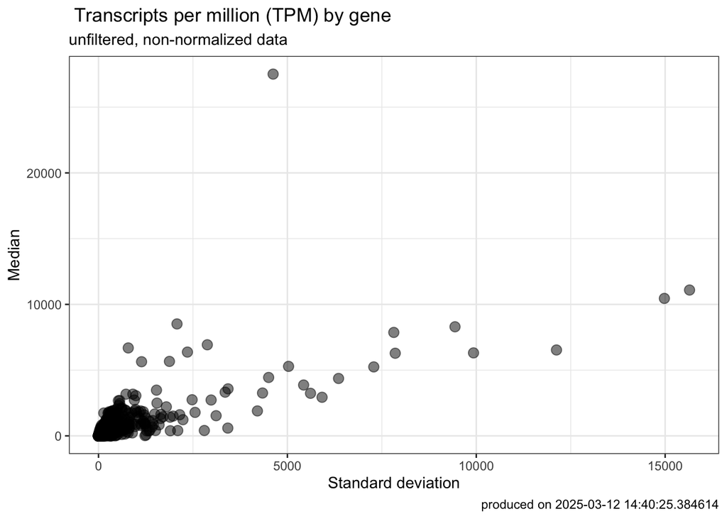

```r
#produce a scatter plot of the TPM data
ggplot(myTPM.stats) +
  aes(x = SD, y = MED) +
  geom_point(shape=19, size=3, alpha = 0.5) +
    labs(y="Median", x = "Standard deviation",
       title=" Transcripts per million (TPM) by gene",
       subtitle="unfiltered, non-normalized data",
       caption=paste0("produced on ", Sys.time())) +
  theme_bw()
```

- From the plot, as gene expression (the number of counts) increases, the standard deviation increases. Therefore, normalization is needed.

# Filtering

## As-is

### Visualizing gene expression across samples (no filtering, no normalization)

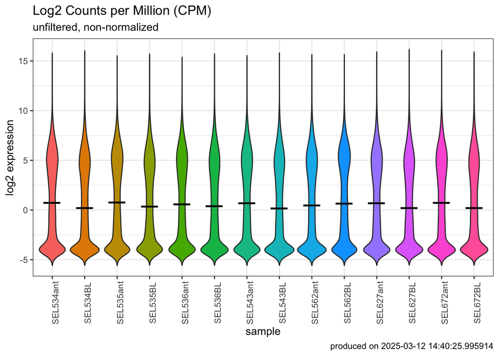

```r
myDGEList <- DGEList(myCounts)

#DEGList objects are a good R data file to consider saving to the working directory
save(myDGEList, file = "myDGEList")

#get log2 cpm
cpm <- cpm(myDGEList) #just counts per million using edgeR
log2.cpm <- cpm(myDGEList, log=TRUE) #gets counts per million values. log=TRUE is a logical argument that then returns log2 values

# 'coerce' your data matrix to a dataframe so that you can use tidyverse tools on it
log2.cpm.df <- as_tibble(log2.cpm, rownames = "geneID") #for gene analysis

# use the tidy package to 'pivot' the dataframe (from wide to long)
log2.cpm.df.pivot <- pivot_longer(log2.cpm.df, # dataframe to be pivoted
                                  cols = SEL534ant:SEL672BL, # column names to be stored as a SINGLE variable
                                  names_to = "samples", # name of that new variable (column)
                                  values_to = "expression") # name of new variable (column) storing all the values (data)

#plot the pivoted data
a <- ggplot(log2.cpm.df.pivot) +
  aes(x=samples, y=expression, fill=samples) +
  geom_violin(trim = FALSE, show.legend = FALSE) +
  stat_summary(fun = "median",
               geom = "point",
               shape = 95,
               size = 10,
               color = "black",
               show.legend = FALSE) +
  labs(y="log2 expression", x = "sample",
       title="Log2 Counts per Million (CPM)",
       subtitle="unfiltered, non-normalized",
       caption=paste0("produced on ", Sys.time())) +
  theme_bw() +
  theme(axis.text.x = element_text(angle = 90))

a
```

```r
##ggsave("gene_level_log2expression_unfiltered_non-normalized_SEL_2025_03_12.pdf", plot = a, dev="pdf")
##ggsave("gene_level_log2expression_unfiltered_non-normalized_SEL_2025_03_12.png", plot = a, dev="png")
```

- The violin plots show a tall distribution of log2cpm where there are many genes with low average expression across individual*tissue (bubble @ bottom). Want to filter these out to remove genes for which we likely don’t have power to statistically test anyway. By decreasing the number of comparisons, we will increase our statistical power.

## Filtered

### Exploration: How many genes aren’t expressed at all (i.e. have “0” reads (aka counts) in all 14 samples)?

```r
table(rowSums(myDGEList$counts==0)>=14) #14 is total number of samples
```

```
##
## FALSE  TRUE
## 21454  1282
```

- We have 1,282 genes that were not expressed in any of our samples and 21,454 genes that were expressed in at least one sample.

### Exploration: How many genes had more than 1 CPM (TRUE) in at least 3 samples (smallest treatment here is N = 3 - the females)?

```r
table(rowSums(cpm>1)>=3)
```

```
##
## FALSE  TRUE
##  9396 13340
```

- From the table, 13,340 genes had more than 1 CPM in at least 3 samples - is only ~60% of original # of comparisons. Filtering to just these should increase our statistical power.

### Retain genes with at least 1 CPM in 3 samples

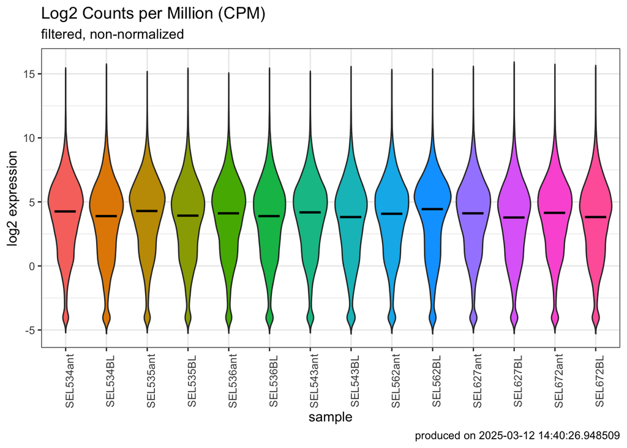

```r
#Assign the imported count data to a variable
counts <- Txi_gene$counts

#get cpm using edgeR package
cpm_counts <- edgeR::cpm(counts)
cpm_more1 <- apply(cpm_counts, 1, function(x) sum(x>1)) #calc total samples each gene has a cpm > 1
idx_keep <- which(cpm_more1>=3) # 3 as the smallest group is females (n = 3)
counts <- counts[idx_keep,]

#get cpm, log2 transform, and plot
myDGEList_filtered <- DGEList(counts)

#DEGList objects are a good R data file to consider saving to the working directory
save(myDGEList_filtered, file = "myDGEList_filtered")

#get log2 cpm
cpm.filtered <- cpm(myDGEList_filtered) #just counts per million using edgeR
log2.cpm.filtered <- cpm(myDGEList_filtered, log=TRUE) #gets counts per million values. log=TRUE is a logical argument that then returns log2 values

# 'coerce' your data matrix to a dataframe so that you can use tidyverse tools on it
log2.cpm.filtered.df <- as_tibble(log2.cpm.filtered, rownames = "geneID") #for gene analysis

# use the tidy package to 'pivot' the dataframe (from wide to long)
log2.cpm.filtered.df.pivot <- pivot_longer(log2.cpm.filtered.df, # dataframe to be pivoted
                                  cols = SEL534ant:SEL672BL, # column names to be stored as a SINGLE variable
                                  names_to = "samples", # name of that new variable (column)
                                  values_to = "expression") # name of new variable (column) storing all the values (data)

#plot the pivoted data
b <- ggplot(log2.cpm.filtered.df.pivot) +
  aes(x=samples, y=expression, fill=samples) +
  geom_violin(trim = FALSE, show.legend = FALSE) +
  stat_summary(fun = "median",
               geom = "point",
               shape = 95,
               size = 10,
               color = "black",
               show.legend = FALSE) +
  labs(y="log2 expression", x = "sample",
       title="Log2 Counts per Million (CPM)",
       subtitle="filtered, non-normalized",
       caption=paste0("produced on ", Sys.time())) +
  theme_bw() +
  theme(axis.text.x = element_text(angle = 90))

b
```

```r
##ggsave("gene_level_log2expression_filtered_non-normalized_SEL_2025_03_12.pdf", plot = b, dev="pdf")
##ggsave("gene_level_log2expression_filtered_non-normalized_SEL_2025_03_12.png", plot = b, dev="png")
```

- Filtering removes a lot of the “bubble” of lowly expressed genes at the bottom

# Normalization

- Testing standard log2 + correction vs vst stabilization

### Define the experimental factors

```r
individual <- factor(coldata$INDIVIDUAL, levels = c("SEL534", "SEL535", "SEL536", "SEL543", "SEL562", "SEL627", "SEL672")) #because ant and leg from same individual they are not independent
sex <- factor(coldata$SEX, levels = c("M", "F")) #because there are sex differences
tissue <- factor(coldata$TISSUE, levels=c("antenna", "leg")) #because there are tissue differences

tissue <- relevel(tissue, "leg") # relevel to "base-line" group
sex <- relevel(sex, "F")
```

### Create model matrix, run DESeq, vst stabilizing transformation

```r
#define the model.matrix
design <- model.matrix(~sex*tissue, coldata)
#design <- model.matrix(~sex + tissue, filter.coldata)

dds <- DESeqDataSetFromMatrix(countData = round(counts),
                              colData = coldata,
                              design = design)

dds <- DESeq(dds)
vsd.fixed <- varianceStabilizingTransformation(dds, blind=F)
vst_expr <- as.data.frame(assay(vsd.fixed), rownames = TRUE)
vst_expr$geneID <- rownames(vst_expr)

#save data as a table
#write_tsv(vst_expr, "./variance_stabilized_counts_2025_03_12.tsv")
```

### Check that vst stabilization is more appropriate compared to log2 transformation

```r
df <- bind_rows(
  as_tibble(log2(counts(dds, normalized=TRUE)[, 1:2])) %>%
    mutate(transformation = "log2"),
  as_tibble(assay(vsd.fixed)[, 1:2]) %>% mutate(transformation = "vst"))

colnames(df)[1:2] <- c("x", "y")

#lvls <- c("log2", "vst", "rlog")
#df$transformation <- factor(df$transformation, levels=lvls)

#ggplot(df, aes(x = x, y = y)) + geom_hex(bins = 80) +
#  coord_fixed() + facet_grid( . ~ transformation)

#meanSdPlot(assay(dds)) #not necessary to plot raw data

ntd <- normTransform(dds)
```

#### log2 mean sd plot

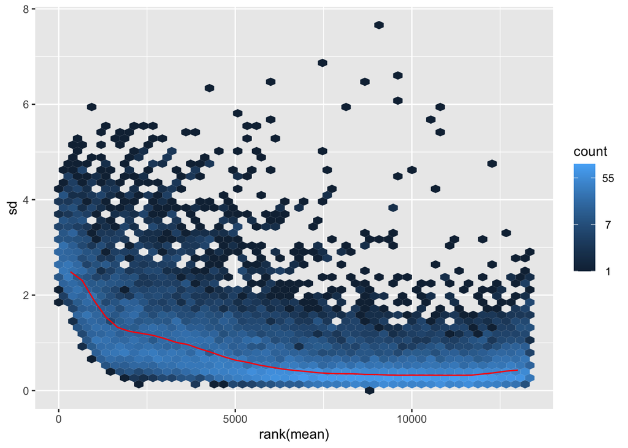

```r
c <- meanSdPlot(assay(ntd))$gg
```

#### variance stabilized mean sd plot

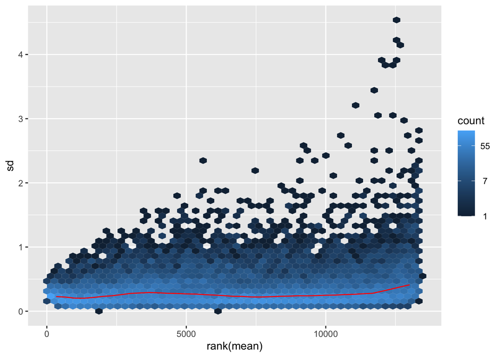

```r
d <- meanSdPlot(assay(vsd.fixed))$gg
```

```r
#e <- meanSdPlot(assay(rld))$gg

#plot_grid(c,d,e, labels = c('c', 'd', 'e'), label_size = 12, ncol = 1, align = "hv")
#plot_grid(c,d, labels = c('c', 'd'), label_size = 12, ncol = 1, align = "hv") #not needed because mean/sd plots printed to screen when call function
```

- Looking at the plots, conducting a variance stabilizing transformation looks more appropriate than a log2 + constant transformation of the count data.